# 6_Keras_Example

${\huge{TensorFlow{~}Modeling{~}using{~}Keras{~}API}}$

TensorFlow is one of Google's contributions to deep learning modeling. It is an open software library that easy runs on Google's cloud-based Jupyter notebook software called Colaboratory. Keras is a high level API, developed by Francois Chollet at Google, that allows users to easily develop models using TensorFLow.

## Image Classification - Handwritten Number Recognition - Deep Learning Model

Both TensorFlow 2.0 and Keras are used to develop a deep learning model that will distinguish between handwritten numbers between 0 and 9.

```python
import warnings
warnings.filterwarnings('ignore')

from matplotlib import pyplot as plt
import numpy as np

import tensorflow as tf
print (tf.__version__)
```

```
2.3.0
```

The MNIST (Modified National Institute of Standards and Technology) dataset contains 60,000 training images (28 pixels x 28 pixels) and 10,000 testing images (28 pixels x 28 pixels).

Load and review some of the images.

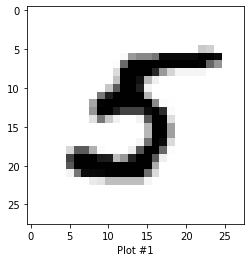

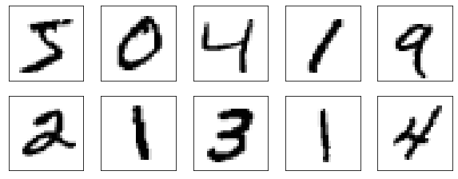

```
- - - - - - - - - - - - - - - - - - Plot #2 - - - - - - - - - - - - - - - - -
```

```python
# Load the data
mnist =  tf.keras.datasets.mnist

(x_train,y_train), (x_test, y_test) = mnist.load_data()




# Review a random sample of the data

# Plot #1 shows a single image from the MNIST dataset
image_index = 5685     # You may select any integer up to and including 59999
plt.xlabel('Plot #1')
plt.imshow(x_train[image_index], cmap='Greys')

# Plot #2 displays the first ten images of the training dataset
plt.figure(figsize=(10,10))
for i in range(10):
    plt.subplot(5,5,i+1)
    plt.xticks([])
    plt.yticks([])
    plt.grid(False)
    plt.imshow(x_train[i], cmap=plt.cm.binary)
plt.show()
print('- - - - - - - - - - - - - - - - - - Plot #2 - - - - - - - - - - - - - - - - -')
```

Next, preprocess the data. In the case of the x dataset divide each x by 255.0 resulting in pixel values range from 0 to 1 rather than 0 to 255. Note also that the values are cast to the appropriate data type.

```python
x_train, x_test = tf.cast(x_train/255.0, tf.float32), tf.cast(x_test/255.0, tf.float32)

y_train, y_test = tf.cast(y_train,tf.int64),tf.cast(y_test,tf.int64)
```

Build the model. Define the model layers. The model is sequential meaning that each layer is stacked on top of the next layer and the model works from top-to-bottom.

The first layer reformats the data by taking a 2D array (image) and flattening it to a 1D array. One can think of this as producing a single row of pixels (numbers) 784 (28 x 28) long.

The next three layers are densely connected or fully connected where each node in the first densely connected layer is connected to each node in the second (or next) layer.

Two of the layers use 'relu' or rectified linear unit as their activation function. Remember, if we didn't apply an activation function then the neuron would merely be applying something similar to linear regression analysis.

The final layer, the output layer, applies the 'softmax' function. Here we have set ten (10) outputs for ten possible digits (0-9); the softmax function takes its inputs and changes each to a probability thus providing the probability for each possible digit given the current image.

The model is then compiled setting the following parameters.

- Optimizer set to 'sgd' or stocastic gradient descent
- Loss set to 'sparce_categorical_crossentropy'
- Metrics set to 'accuracy'

```python
model = tf.keras.models.Sequential()

model.add(tf.keras.layers.Flatten())
model.add(tf.keras.layers.Dense(256, activation="relu"))
model.add(tf.keras.layers.Dense(128, activation="relu"))
model.add(tf.keras.layers.Dense(10, activation="softmax"))

model.compile(optimizer='sgd', loss='sparse_categorical_crossentropy', metrics=['accuracy'])

model.fit(x_train, y_train, batch_size=32, epochs=3)

print('\nResults of Applying Model to Test Data')
model.evaluate(x_test, y_test)

test_loss, test_acc = model.evaluate(x_test, y_test, verbose=2)

print('As Displayed Above, Model Accuracy on Test Data: {:5.4f}' .format (test_acc))
```

```
Results of Applying Model to Test Data
313/313 - 0s - loss: 0.2004 - accuracy: 0.9407
As Displayed Above, Model Accuracy on Test Data: 0.9407
```

# Using the model to predict the handwritten digit in a specific image.

The model can be used to predict the probability of each image being a specific digit.

```python
probability_model = tf.keras.Sequential([model, tf.keras.layers.Softmax()])
predictions = probability_model.predict(x_test)
```

Using the first image in the test dataset, the model has shown the number '7' has the greatest probablity of being the correct digit.

```python
predictions[0]
```

```
array([0.08539068, 0.08538902, 0.08541839, 0.08557831, 0.08538909,
       0.08539802, 0.08538896, 0.23114164, 0.08539107, 0.08551483],
      dtype=float32)
```

Let's get the Model to display the predicted digit.

```python
np.argmax(predictions[0])
```

```
7
```

Finally, we can see for ourselves what the first digit is in the test dataset. Let's display the first five (5) digits in the test dataset.

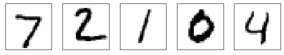

```
- - - - - - - - - - - - - - - - - - Plot #3 - - - - - - - - - - - - - - - - -
```

```python
# Plot #3 displays the first five images of the test dataset
plt.figure(figsize=(10,10))
for i in range(5):
    plt.subplot(5,5,i+1)
    plt.xticks([])
    plt.yticks([])
    plt.grid(False)
    plt.imshow(x_test[i], cmap=plt.cm.binary)
plt.show()
print('- - - - - - - - - - - - - - - - - - Plot #3 - - - - - - - - - - - - - - - - -')
```

The first image in the test dataset is in fact the handwritten number '7'.